# 2.1. Filtrations and Counting Processes

지금까지 챕터 1에서는 Kaplan Meier estimator에 대해 배웠고, 어떻게 Survival probability $S(t)$를 추정하는지 배웠다. 또한 그를 통해 어떻게 cumulative hazard function $A(t)$를 추정하는지, 또 그 둘의 one to one 관계에 대해 배웠다. 하지만 Kaplan Meier estimator를 통해 추정한 $S(t)$는 nonparametric estimator임을 명심하자. 때문에 이전 챕터에서 우리는 Greenwood’s formula를 통해 $S(t)$의 pointwise한 confidence interval을 추정했다. 이에 확장하여 앞으로의 우리의 목표는 CLT를 통해 $S(t)$의 global confidence band를 추정하는 것이다. 이번 챕터부터는 그 전에 배웠던 Probability Theory와 Measure Theory 부분이 많이 이용되니 그 부분에 대한 확실한 예습이 필요하다.

매우 중요하다

#### Definition (Filtrations)

Let $(\Omega, \mathcal{F}, P)$ be a probability space, and let $\mathcal{T}\subset \mathbb{R}$ be an interval of the form $[0,\tau)$ or $[0,\tau]$. A filtration is a family $\{\mathcal{F}_t, t\in \mathcal{T}\}$ of sub-$\sigma$-fileds of $\mathcal{F}$ that is:

- increasing, i.e., for $s<t$, $\mathcal{F}_s\subset \mathcal{F}_t$,
- right continuous, i.e., $\mathcal{F}_s= \cap_{t>s}\mathcal{F}_t$,
- complete, i.e., if $B\in \mathcal{F}$ is such that $P(B)=0$ and $A\subset B$, then $A\in\mathcal{F}_0$ where $\mathcal{F}_0=\{\phi,\Omega\}$.

Note that a stochastic process $U(\cdot)$ is adapted to the filtration if for each $t$, $U(t)\in \mathcal{F}_t$.

- Filtration에서의 $\mathcal{F}_t$은 “all information available at time $t$”의 의미이다.
- For example, $\mathcal{F}_t$ is the $\sigma$-field generated by the process up to time $t$: for any $s<t$, consider $N_s(\cdot)$, and $\{\omega|N_s(\omega)\in B\}$ for all $B$, a Borel subset of $\mathbb{R}$. 즉 $\mathcal{F}_t$는 $t$시점까지(쉽게 $t$시점에서 불과 0.01초 직전까지 ,e.g. $s=t-$)의 모든 정보를 의미한다.
- 예를 들어 regression에서 $\mathcal{F}_0$는 covariate information at the start of the study이고, $\mathcal{F}_t$는 join of $\mathcal{F}_0$ and the $\sigma$-field generated by the process up to time $t$라고 생각할 수 있다.
- increasing의 의미는 쉽게 해석하자면 $s<t$에 대해 $t$시점에서는 그 모든 전 시점 $s<t$에 대한 정보를 갖고 있지만, $s$시점에서는 $t$시점의 정보를 모른다는 의미로 해석할 수 있다.
- right continuity는 $s<t$에 대해 increasing property에 의해 당연히 $\mathcal{F}_s\subset \cap_{t>s}\mathcal{F}_t$이기 때문에 $\mathcal{F}_s \supset \cap_{t>s}\mathcal{F}_t$을 의미한다. 이는 $s=t-$라고 한다면 즉 **there is no information “just after” time $t-$**의 의미이다.
- Complete의 의미는 $\mathcal{F}$의 원소인 $B$에 대해 $P(B)=0$, i.e., set $B$의 probability measure가 0이면, $B$에 대한 모든 subset들은 trivial $\sigma$-filed인 $\mathcal{F}_0$의 원소라는 의미이다. 이는 즉, probability가 0인 event들에게선 우리는 아무런 정보를 얻을 수 없다는 의미이다.
- A stochastic process $U(\cdot)$에 대해, $U(t)\in\mathcal{F}_t$의 의미는, for any Borel subset $B\in \mathbb{R}$에 대해 $U(t)$ is a random variable such that
  $$\{U(t)^{(\omega)}\in B\}\in \mathcal{F}_t, \mbox{ }\mbox{ }\mbox{ where } \mbox{ }\mbox{ }U_t:\Omega\rightarrow \mathbb{R}$$
  의 의미이다.

##### Definition(Counting Process)

Given a filtration $\{\mathcal{F}_t,t\in \mathcal{T}\}$, a multivariate counting process $N=(N_1,\ldots,N_k)$ is a vector of stochastic processes that

- are adapted,
- are 0 at time 0,
- are continuous from the right
- are nondecreasing,
- have jumps of size +1 only,
- are such that no two processes jupt at the same time.

We suppose that each process is almost surely finite for all $t\in \mathcal{T}$.

- 아래의 그림을 참고하자.

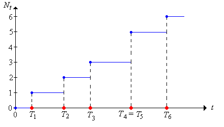

- Note that $N_t\stackrel{\text{let}}=N(t)$ is the random variable of stochastic process where $N_t:\Omega\rightarrow \mathbb{R}$이다.
- adapted 의 의미는 **adapted to the filtration**의 의미로, for all Borel subset $B \in \mathbb{R}$
  $$\{N_t\in B\}\in \mathbb{F}_t$$
  이다, i.e., at time $t$, we need to be able to dethermine whether this occured or not.
- $N=(N_1,\ldots,N_k)$에서 $k$는 sample number를 의미한다. 후에 $k$-sample problem을 다룰 것이다.

##### 예제 1

The Poisson process. Let $\mathcal{F}_t$ be the $\sigma$-filed generated by the process up to time $t$.

- 아래의 그림을 참고하자.

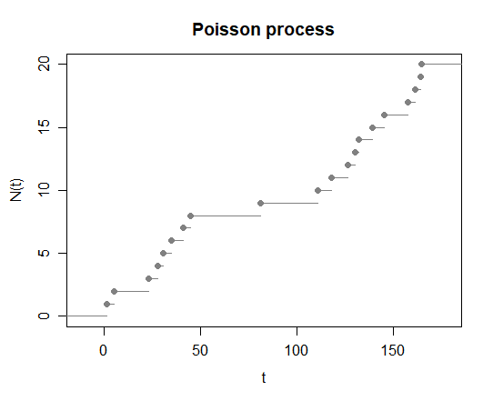

##### 예제 2

Let $X$ be a positive random variable, and let $N(t)=I(X\le t)$, $t\in [0,\infty)$. Let $\mathcal{F}_t$ be the $\sigma$-field generated by the process up to time $t$. Then, $N$ is a one-dimensional counting process which has exactly one jump.

##### 예제 3

Consider the situation of random right censoring, with $n=1$. Let $N(t)=I(Z\le t, \delta=1)$, $t\in [0,\infty)$. Again, let $\mathcal{F}_t$ be the $\sigma$-field generated by the process up to time $t$. Then, $N$ is a one-dimensional counting process which has at most one jump (즉, 만약 relapsed된 경우라면, one jump가 있고, censoring된 경우라면 jump가 없는 경우이다).

back